# Lab 08 – Multiple Linear Regression

Vineeth Kotala

# Getting started

In this assignment, you will apply multiple regression tools to the Boston Housing Data, which consist of housing values in suburbs of Boston taken from the 1970 Census. The data set also contains other information that may affect house prices, such as the crime rate in the area and the proportion of owner-occupied houses. The data set and data dictionary can be found at [Boston Housing Data](https://archive.ics.uci.edu/ml/machine-learning-databases/housing/).

In RStudio, create a folder called `lab-07` and set this folder as your working directory. Run the following commands to download to your lab directory the `housing.data` and `housing.names` files from the Boston Housing Data archive to a sub-directory of called `data_housing`.

```r
library(tidyverse)

# Make data directory
dir.create("data_housing")

# Download data
"https://archive.ics.uci.edu/ml/machine-learning-databases/housing/housing.data" %>%
  download.file("data_housing/housing.data")

# Download data dictionary
"https://archive.ics.uci.edu/ml/machine-learning-databases/housing/housing.names" %>%
  download.file("data_housing/housing.names")

# Variable names from housing.names
variables <- c("CRIM", "ZN", "INDUS",  "CHAS", "NOX", "RM", "AGE",
               "DIS", "RAD", "TAX", "PTRATIO", "B", "LSTAT", "MEDV")

# Read in the data
housing_data <- read_table("data_housing/housing.data", col_names = variables)
```

# Problem 1: Linear regression

1. Using `ggplot`, create a scatter plot with the median value of owner-occupied homes (in $1000’s) on the vertical axis and the weighted distances to five Boston employment centers on the horizontal axis. Add a linear trendline to the graph using the `geom_smooth` command. Does the graph suggest that the systematic relationship between these two variables is linear or non-linear? Briefly discuss.

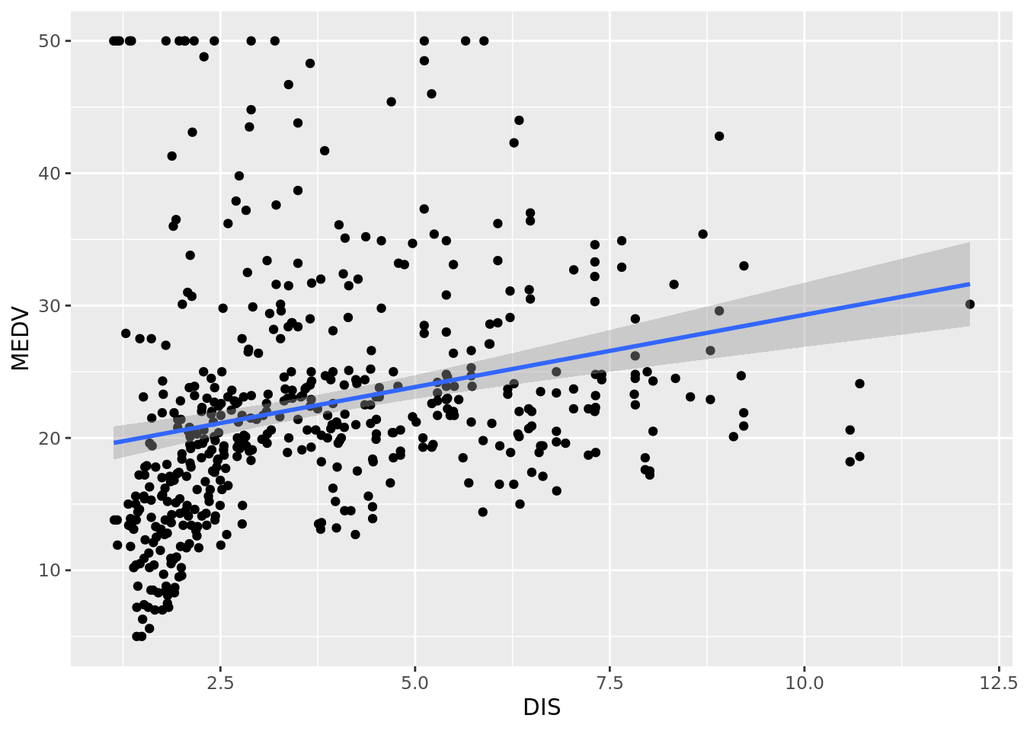

```r
# Scatter plot
housing_data%>%
  ggplot(aes(x = DIS, y = MEDV))+
  geom_point()+
  geom_smooth(method = lm)
```

The graph says that the relationship between MEDV & DIS is non linear, it looks more like a converging rate

2. Estimate a simple linear model where the outcome is the median value of owner-occupied homes (in $1000’s) and the explanatory variable is the weighted distances to five Boston employment centers. Save the result of this regression in a variable called `lm_dis` and display the results using the `stargazer` function.

```r
# Simple linear regression
lm_dis <- lm(MEDV ~ DIS, housing_data)

# Show regression output using stargazer function

library(stargazer)
stargazer(lm_dis, type="text" )
```

```
##
## ===============================================
##                         Dependent variable:
##                     ---------------------------
##                                MEDV
## -----------------------------------------------
## DIS                          1.092***
##                               (0.188)
##
## Constant                     18.390***
##                               (0.817)
##
## -----------------------------------------------
## Observations                    506
## R2                             0.062
## Adjusted R2                    0.061
## Residual Std. Error      8.914 (df = 504)
## F Statistic           33.580*** (df = 1; 504)
## ===============================================
## Note:               *p<0.1; **p<0.05; ***p<0.01
```

3. We often describe an estimate as “statistically significant” at the 95% confidence level if the estimate is more than 1.96 (i.e., about 2) standard errors away from zero. Is the estimated parameter on the distance variable statistically significant?

Yes; p-value < 1%

4. Is the following a valid interpretation of the regression results (discuss)? “Median home values tend to be higher, by about $1,000 per mile, for neighborhoods located further from employment centers.”

No, it is not linear. Therefore the above interpretation is not valid

5. Is the following a valid interpretation of the regression results (discuss)? “All else equal, being located further from employment centers causes median home values to decrease.”

# Problem 2: Mean Squared Error (MSE)

1. What is the “mean squared error” (MSE) of the `lm_dis` model you have estimated? Hint: MSE is calculated as the average value of squared prediction errors for all observations in the data.

```r
# Calculate MSE of the model
mean(lm_dis$residuals^2)
```

```
## [1] 79.14634
```

2. Add to the `housing_data` data frame 10 new variables called `random_var1` - `random_var10`, where each variable is defined to be a random number drawn uniformly from the interval from -1 to 1. Estimate a linear model named `lm_plus` that builds on the `lm_dis` model, but adds the `random_varX` variables as additional explanatory variable. How does the MSE of `lm_plus` compare to that of `lm_dis`? What do these results imply about using MSE as a criterion for selecting whether a model with more predictors is better than a simpler model with fewer controls?

```r
# Set the seed for replicability
set.seed(2)

# Add random_var to the data frame
random_var = paste0("random_var",1:10)


for (i in random_var){
  housing_data[i] <- runif(nrow(housing_data),-1, 1)}

head(housing_data)
```

```
## # A tibble: 6 × 24
##      CRIM    ZN INDUS  CHAS   NOX    RM   AGE   DIS   RAD   TAX PTRATIO     B
##     <dbl> <dbl> <dbl> <dbl> <dbl> <dbl> <dbl> <dbl> <dbl> <dbl>   <dbl> <dbl>
## 1 0.00632    18  2.31     0 0.538  6.58  65.2  4.09     1   296    15.3  397.
## 2 0.0273      0  7.07     0 0.469  6.42  78.9  4.97     2   242    17.8  397.
## 3 0.0273      0  7.07     0 0.469  7.18  61.1  4.97     2   242    17.8  393.
## 4 0.0324      0  2.18     0 0.458  7.00  45.8  6.06     3   222    18.7  395.
## 5 0.0690      0  2.18     0 0.458  7.15  54.2  6.06     3   222    18.7  397.
## 6 0.0298      0  2.18     0 0.458  6.43  58.7  6.06     3   222    18.7  394.
## # … with 12 more variables: LSTAT <dbl>, MEDV <dbl>, random_var1 <dbl>,
## #   random_var2 <dbl>, random_var3 <dbl>, random_var4 <dbl>, random_var5 <dbl>,
## #   random_var6 <dbl>, random_var7 <dbl>, random_var8 <dbl>, random_var9 <dbl>,
## #   random_var10 <dbl>
```

```r
# Calculate lm_plus model
lm_plus <- lm(MEDV ~ DIS + random_var1 + random_var2 + random_var3 + random_var4, housing_data)

summary(lm_plus)
```

```
##
## Call:
## lm(formula = MEDV ~ DIS + random_var1 + random_var2 + random_var3 +
##     random_var4, data = housing_data)
##
## Residuals:
##     Min      1Q  Median      3Q     Max
## -15.078  -5.501  -1.843   2.411  30.679
##
## Coefficients:
##             Estimate Std. Error t value Pr(>|t|)
## (Intercept) 18.38176    0.82310  22.332  < 2e-16 ***
## DIS          1.09347    0.18953   5.769  1.4e-08 ***
## random_var1 -0.41965    0.66583  -0.630    0.529
## random_var2 -0.31277    0.68154  -0.459    0.646
## random_var3  0.06232    0.66483   0.094    0.925
## random_var4  0.38303    0.69495   0.551    0.582
## ---
## Signif. codes:  0 '***' 0.001 '**' 0.01 '*' 0.05 '.' 0.1 ' ' 1
##
## Residual standard error: 8.942 on 500 degrees of freedom
## Multiple R-squared:  0.06415,    Adjusted R-squared:  0.05479
## F-statistic: 6.855 on 5 and 500 DF,  p-value: 3.356e-06
```

```r
summary(lm_dis)
```

```
##
## Call:
## lm(formula = MEDV ~ DIS, data = housing_data)
##
## Residuals:
##     Min      1Q  Median      3Q     Max
## -15.016  -5.556  -1.865   2.288  30.377
##
## Coefficients:
##             Estimate Std. Error t value Pr(>|t|)
## (Intercept)  18.3901     0.8174  22.499  < 2e-16 ***
## DIS           1.0916     0.1884   5.795 1.21e-08 ***
## ---
## Signif. codes:  0 '***' 0.001 '**' 0.01 '*' 0.05 '.' 0.1 ' ' 1
##
## Residual standard error: 8.914 on 504 degrees of freedom
## Multiple R-squared:  0.06246,    Adjusted R-squared:  0.0606
## F-statistic: 33.58 on 1 and 504 DF,  p-value: 1.207e-08
```

# Problem 3: Multiple linear regression

1. Building on the simple linear model `lm_dis` from Problem 1, estimate a multiple linear regression of `MEDV` that also controls for the full-value property-tax rate per $10,000. Save the result of this regression in a variable called `lm_tax`.

```r
# Estimate the model
lm_tax <- lm(MEDV~ DIS + TAX, data = housing_data)
```

2. Building on the linear model `lm_tax`, estimate a multiple linear regression of `MEDV` that also controls for nitric oxides concentration (parts per 10 million). Save the result of this regression in a variable called `lm_nox`.

```r
# Estimate the model
lm_nox <- lm(MEDV~ DIS + TAX + NOX, housing_data)
```

3. Building on the simple linear model `lm_nox`, estimate a multiple linear regression of `MEDV` that also controls for percent of the population with low socioeconomic status. Save the result of this regression in a variable called `lm_ses`.

```r
# Estimate the model
lm_ses <- lm(MEDV~ DIS + TAX + NOX + LSTAT, housing_data)
head(housing_data)
```

```
## # A tibble: 6 × 24
##      CRIM    ZN INDUS  CHAS   NOX    RM   AGE   DIS   RAD   TAX PTRATIO     B
##     <dbl> <dbl> <dbl> <dbl> <dbl> <dbl> <dbl> <dbl> <dbl> <dbl>   <dbl> <dbl>
## 1 0.00632    18  2.31     0 0.538  6.58  65.2  4.09     1   296    15.3  397.
## 2 0.0273      0  7.07     0 0.469  6.42  78.9  4.97     2   242    17.8  397.
## 3 0.0273      0  7.07     0 0.469  7.18  61.1  4.97     2   242    17.8  393.
## 4 0.0324      0  2.18     0 0.458  7.00  45.8  6.06     3   222    18.7  395.
## 5 0.0690      0  2.18     0 0.458  7.15  54.2  6.06     3   222    18.7  397.
## 6 0.0298      0  2.18     0 0.458  6.43  58.7  6.06     3   222    18.7  394.
## # … with 12 more variables: LSTAT <dbl>, MEDV <dbl>, random_var1 <dbl>,
## #   random_var2 <dbl>, random_var3 <dbl>, random_var4 <dbl>, random_var5 <dbl>,
## #   random_var6 <dbl>, random_var7 <dbl>, random_var8 <dbl>, random_var9 <dbl>,
## #   random_var10 <dbl>
```

4. Report regressions results from all four models above in the same table using the `stargazer()` command. What can we learn from these regressions about the relationship between distance to employment centers and median home values?

```r
stargazer(lm_dis, lm_tax, lm_nox, lm_ses,  type = "text", omit.stat = "all", table.layout = "#t")
```

```
##
##             (1)       (2)       (3)        (4)
## DIS      1.092***   -0.003   -0.917***  -1.206***
##           (0.188)   (0.204)   (0.262)    (0.197)
##
## TAX                -0.026*** -0.018***  -0.008***
##                     (0.003)   (0.003)    (0.002)
##
## NOX                          -28.794*** -8.890**
##                               (5.418)    (4.187)
##
## LSTAT                                   -0.941***
##                                          (0.048)
##
## Constant 18.390*** 32.989*** 49.525***  47.152***
##           (0.817)   (1.632)   (3.494)    (2.623)
##
```

We can say from above that when we consider tax and distance, MDEV is independent of the Distance variable. Other variables like NOX and LSTAT are statistically significant.

Also before inclusion of other variables, Dis coefficient was positive and has turned out to be negative after inclusion of other variables, so relation between DIS and MEDV could be non linear

# Problem 4: Non-linear Regression

1. Estimate a quartic (4th degree polynomial) relationship between median home values and distance to employment centers. Do this “manually” by constructing each of the polynomial terms as new variables in the data frame. Assign the regression results to `lm_dis_man`. Create a scatter plot of median home values versus distance, and add a line plot layer showing the predicted values from this model. Choose a nice color for this line plot (e.g., firebrick red) to help it to stand out against the black scatter plot markers.

```r
# Add DIS_2-DIS_4 to the data frame

housing_data$DIS_2 <- housing_data$DIS^2


housing_data <- housing_data%>%
  mutate(DIS_3= DIS^3, DIS_4= DIS^4)
head(housing_data)
```

```
## # A tibble: 6 × 27
##      CRIM    ZN INDUS  CHAS   NOX    RM   AGE   DIS   RAD   TAX PTRATIO     B
##     <dbl> <dbl> <dbl> <dbl> <dbl> <dbl> <dbl> <dbl> <dbl> <dbl>   <dbl> <dbl>
## 1 0.00632    18  2.31     0 0.538  6.58  65.2  4.09     1   296    15.3  397.
## 2 0.0273      0  7.07     0 0.469  6.42  78.9  4.97     2   242    17.8  397.
## 3 0.0273      0  7.07     0 0.469  7.18  61.1  4.97     2   242    17.8  393.
## 4 0.0324      0  2.18     0 0.458  7.00  45.8  6.06     3   222    18.7  395.
## 5 0.0690      0  2.18     0 0.458  7.15  54.2  6.06     3   222    18.7  397.
## 6 0.0298      0  2.18     0 0.458  6.43  58.7  6.06     3   222    18.7  394.
## # … with 15 more variables: LSTAT <dbl>, MEDV <dbl>, random_var1 <dbl>,
## #   random_var2 <dbl>, random_var3 <dbl>, random_var4 <dbl>, random_var5 <dbl>,
## #   random_var6 <dbl>, random_var7 <dbl>, random_var8 <dbl>, random_var9 <dbl>,
## #   random_var10 <dbl>, DIS_2 <dbl>, DIS_3 <dbl>, DIS_4 <dbl>
```

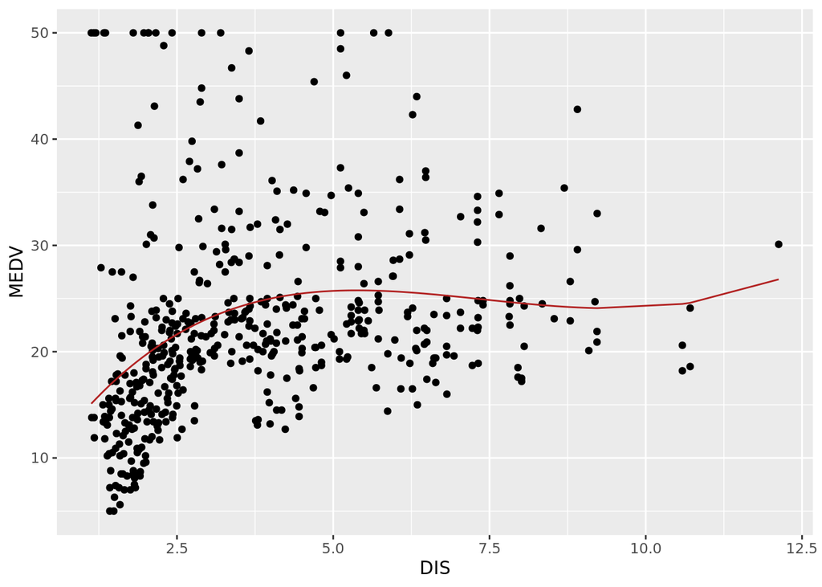

```r
# Estimate the model

lm_dis_man <- lm(MEDV ~ DIS + DIS_2 + DIS_3 + DIS_4, housing_data)



# Scatter plot with model predicted values

ggplot(housing_data)+
  geom_point(aes(x = DIS, y = MEDV))+
  geom_line(aes(DIS, lm_dis_man$fitted.values), color="firebrick")
```

2. Use the `poly()` function in the regression formula to estimate the same quartic model in the previous question. For this question, you should not construct any new variables yourself. Save the results to a variable called `lm_dis_poly`. Use the `all.equal()` command to confirm that the estimated coefficients and predicted values from the `lm_dis_man` and `lm_dis_poly` models are the same.

```r
# Estimate the model
lm_dis_poly = lm(MEDV~ poly(DIS, 4, raw = TRUE), data= housing_data)

# Confirm that lm_dis_man and lm_dis_poly coefficients are equal

all.equal(lm_dis_man$coefficients, lm_dis_poly$coefficients, check.names= FALSE)
```

```
## [1] TRUE
```

```r
# Confirm that lm_dis_man and lm_dis_poly predicted values are equal
all.equal(lm_dis_man$fitted.values, lm_dis_poly$fitted.values, check.names= FALSE)
```

```
## [1] TRUE
```

3. The `lm_dis_man` and `lm_ses` models both have 4 predictor variables. Calculate the MSE for each model. Do you think the model with a lower MSE is better than the model with the higher MSE? How does your answer compare to or differ from your answer to Problem 2.2 above? Briefly discuss.

```r
MSE_lm_dis_man <- mean(lm_dis_man$residuals^2)
MSE_lm_dis_man
```

```
## [1] 75.5509
```

```r
MSE_lm_ses <- mean(lm_ses$residuals^2)
MSE_lm_ses
```

```
## [1] 35.02576
```

```r
mean(lm_plus$residuals^2)
```

```
## [1] 79.00377
```

```r
mean(lm_dis$residuals^2)
```

```
## [1] 79.14634
```

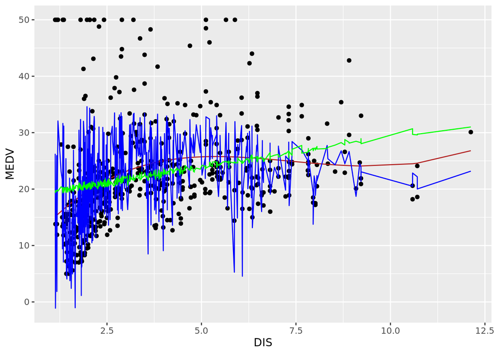

```r
ggplot(housing_data)+
  geom_point(aes(x = DIS, y = MEDV))+
  geom_line(aes( DIS, lm_dis_man$fitted.values), color="firebrick")+
  geom_line(aes( DIS, lm_ses$fitted.values), color="blue")+
  geom_line(aes(DIS, lm_plus$fitted.values), color="green")
```

In the case of lm_ses- MSE is significantly reduced, compared to those of lm_plus and lm_ses; But the additional predictors of lm_plus are random numbers which did not improve fitting and any marginal increase is because of random noise and in the case of lm_ses although MSE is low, the fitting is not useful for prediction which is a case of over-fitting.The lm_dis_man better gives the movement of MEDV wrt variables DIS.